# Chapter 9 Homework

AP

2/5/2022

## Question 1

Natural experiment

## Question 2

The isolated variation in the treatment cannot be on a path that has back doors.

We know randomized controlled experiments do this because the variation in treatment is randomly assigned by a researcher, so any variation in any variables on a back door path is unrelated to whether or not they end up getting the treatment.

## Question 3

There might be open back door paths in a natural experiment, which wouldn’t happen in an RCT.

There’s not a volunteer selection effect, and the results you see have more mundane realism.

We only see the effect of the treatment among people who are sensitive to the source of randomness in our natural experiment.

There’s a higher burden of proof to convince people you’ve closed all the relevant back doors.

## Question 4

Does incarceration decrease life expectancy?

You can’t ethically randomly assign people to be incarcerated.

## Question 5

Exogenous variation is variation in the treatment that has no open back doors and ideally is caused by a source that in turn isn’t caused by any other variable in the DAG.

## Question 6

Using Hurricane Katrina as a source of random variation in neighborhood residence to examine the effect of neighborhood on recidivism rates (Kirk, 2009, ASR).

The variables in the diagram below are neighborhood (nbhd), recidivism (rec), personality (pers), family characteristics (fam), and Hurricane Katrina (kat).

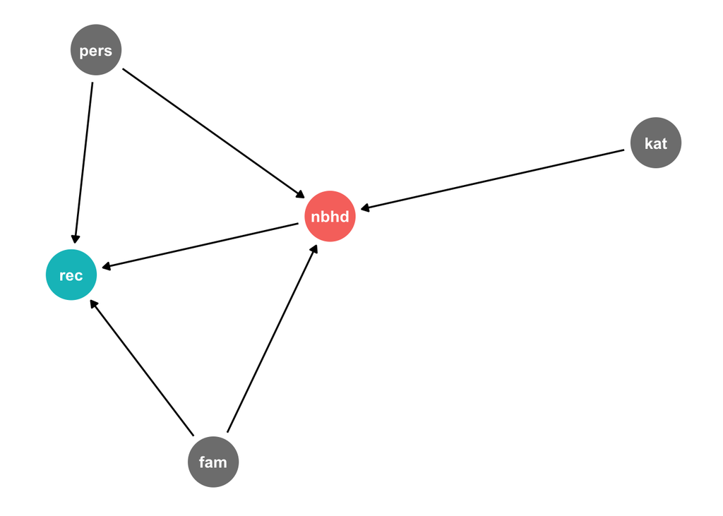

```r
q6dag <- dagify(rec ~ nbhd + pers + fam,
                nbhd ~ pers + fam + kat,
                exposure = "nbhd",
                outcome = "rec"
      )
set.seed(18)
ggdag_status(q6dag) + theme_dag() + theme(legend.position = "none")
```

Katrina $\rightarrow$ Neighborhood $\rightarrow$ Recidivism

Katrina $\rightarrow$ Neighborhood $\leftarrow$ Family Characteristics $\rightarrow$ Recidivism

Katrina $\rightarrow$ Neighborhood $\leftarrow$ Personality $\rightarrow$ Recidivism

The back door paths on this diagram don’t need to be closed (they’re already closed because of colliders). However, the author of this study points out other possible back door paths that he controls for: “The statistical models include controls for segregation, average household income, the unemployment rate, average weekly wages, and fair market rents.”

I am personally convinced that the author closed all pertinent back door paths.

## Question 7

B

## Question 8

Tariffs $\leftarrow$ Trump $\rightarrow$ Brazil’s opinion of the U.S

If someone ran this experiment as described I would be skeptical - it could be that increased trade positively affected Brazil’s opinion of the U.S. but it was outweighed by the negative effect of Trump on Brazil’s opinion of the U.S. It’s not an ideal source of exogenous variation because it was in turn caused by a variable that’s relevant to the outcome.